# Simple Linear Regression

```r
# Load your libraries
library(car)
library(tidyverse)
library(readr)
library(pander)
# Load your data after saving a csv file in your Data folder.
# You can use either
#   someName <- read.csv("../Data/YourDataFileName.csv", header=TRUE)
# or
#   library(readr)
#   someName <- read_csv("../Data/YourDataFileName.csv")

# Don't forget to run "Session -> Set Working Directory -> To Source file location"

steps_to_calories <- read_csv("../../linear_regression_data.csv")
```

## Background

I collected walking data off of my google fit app. This app tracks my steps and how many calories I burn through the day walking. I put this data in a CSV file and will do a linear regression analyses to see if there is a relationship between amount of steps taken and the amount of calories I burn.

## Question and Hypotheses:

- Is there a linear relationship between steps walked and calories burned?
- Null Hypotheses : the slope is equal to 0.
- Alternative Hypotheses : the slope is not equal to 0.

## Analysis

```r
steps_lm <- lm(calories_burned ~ steps_walked, data = steps_to_calories)
summary(steps_lm) %>% pander()
```

|  | Estimate | Std. Error | t value | Pr(>\|t\|) |
| --- | --- | --- | --- | --- |
| **(Intercept)** | -1919 | 161.2 | -11.9 | 2.99e-12 |
| **steps_walked** | 1.346 | 0.1057 | 12.74 | 6.267e-13 |

Fitting linear model: calories_burned ~ steps_walked

| Observations | Residual Std. Error | $R^2$ | Adjusted $R^2$ |
| --- | --- | --- | --- |
| 29 | 19.71 | 0.8573 | 0.852 |

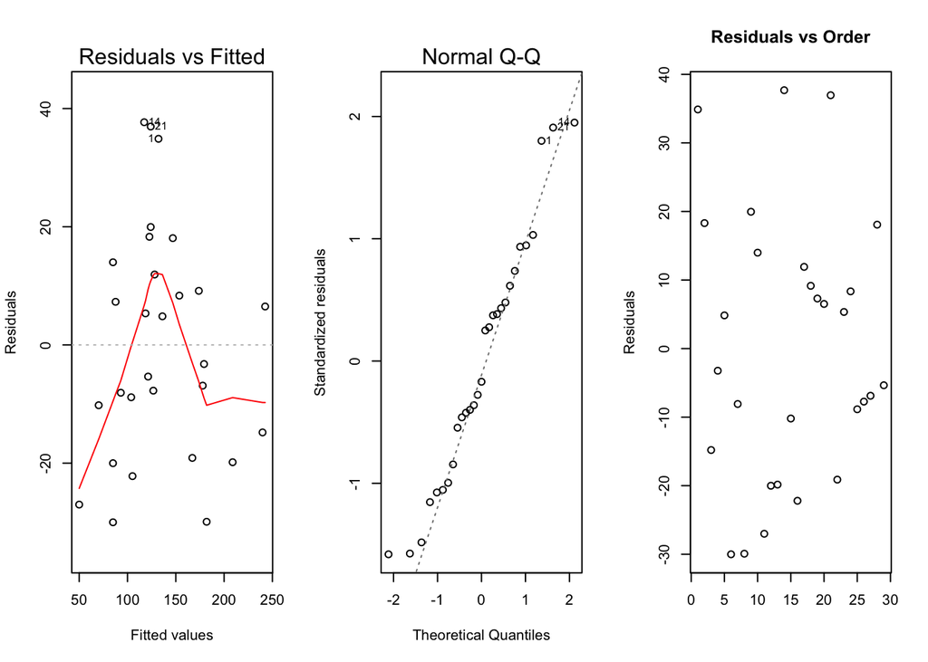

```r
par(mfrow=c(1,3))
plot(steps_lm, which=1:2)
plot(steps_lm$residuals, main = "Residuals vs Order", xlab = "", ylab = "Residuals")
```

The simple linear regression analyses is a good test for this because:

1. There seems to be a linear relationship.
2. The error terms seem to be normaly distributed.
3. The variance is constant.
4. The x values are measured and fixed without error.
5. The error terms are independent.

These 5 points can be checked with the residuals and the Q-Q plot.

We will use an alpha of 0.05 with this test. The P values are lower than this so we will reject the null.

## Graph

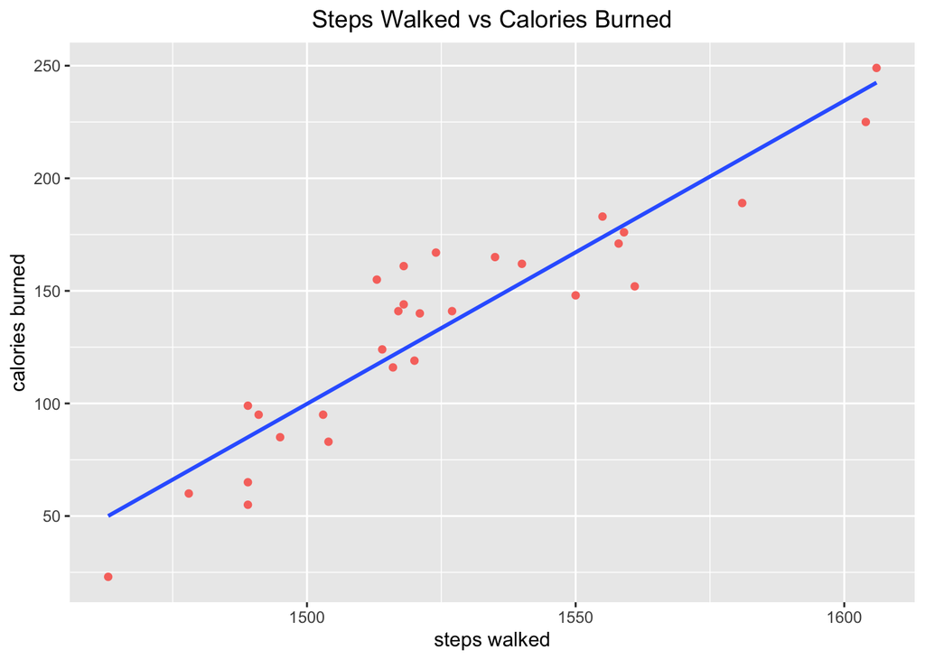

```r
ggplot(data = steps_to_calories) +
  geom_point(mapping = aes(x = steps_walked, y = calories_burned, color = "orangered3")) +
  geom_smooth(method = lm, se = FALSE, mapping = aes(x = steps_walked, y = calories_burned)) +
  labs(title = "Steps Walked vs Calories Burned", x = "steps walked", y = "calories burned") +
  theme(plot.title = element_text(hjust = 0.5),
        legend.position = "none")
```

The graph shows a very strong positive linear relationship between steps walked and calories burned

## Interpretation

The slope is 1.346 and the r-squared value is 0.8573 which shows a strong positive linear relationship between steps walked and calories burned.

## Conclusion

There is a positive strong linear relationship between steps walked and calories burned. We can reject the null hypotheses.